# Lab 3

Tessa Mendoza and Becca Barrick

9/27/2020

```r
dat <- readxl::read_xls('GSS.xls')
library(tidyverse)
```

**1) Find the average years of education for the respondents with each political party affiliation. Arrange your output in a meaningful order and print. Describe any patterns you find.**

```r
dat <- slice(dat, 1:(n()-2))
dat <- dat %>% rename('education' = `Highest year of school completed`,
                      'age' = `Age of respondent`, party = `Political party affiliation`, 'marriage' = `Marital status`, 'happy' = `General happiness`)

dat <- dat %>%
  mutate(education = as.numeric(education),
         age = as.numeric(age)) %>%
  mutate(party = factor(party))

meanEdu <- dat %>%
  filter(!is.na(education)) %>%
  group_by(party) %>%
  summarize(mean_education = mean(education)) %>%
  arrange(desc(mean_education))
meanEdu
```

```
## # A tibble: 10 x 2
##    party              mean_education
##    <fct>                       <dbl>
##  1 Strong republican            13.4
##  2 Other party                  13.4
##  3 Ind,near rep                 13.3
##  4 Not str republican           13.3
##  5 Ind,near dem                 13.2
##  6 Not str democrat             12.6
##  7 Strong democrat              12.5
##  8 Independent                  12.3
##  9 No answer                    12.3
## 10 Don't know                   10.9
```

While the mean number of years is similar between each political party group and ranges from 10-13 years, there is one noticable pattern: those who do not know their political party tend to have a lower amount of education (on average, through part of high school). This suggests that those with higher education tend to have a more distinguished indentification with a political party.

**2) Create a single data frame containing records for the better educated respondents in each political party affiliation. A “better educated” respondent is someone who has strictly more years of education than the median in the same party affiliation. Print the structure of the data frame.**

```r
betterEdu <- dat %>%
  filter(!is.na(education)) %>%
  group_by(party) %>%
  filter(education > median(education, na.rm = TRUE)) %>%
  ungroup()
str(betterEdu)
```

```
## tibble [27,840 × 10] (S3: tbl_df/tbl/data.frame)
##  $ Gss year for this respondent: num [1:27840] 1972 1972 1972 1972 1972 ...
##  $ happy                       : chr [1:27840] "Not too happy" "Not too happy" "Pretty happy" "Not too happy" ...
##  $ party                       : Factor w/ 10 levels "Don't know","Ind,near dem",..: 2 6 2 2 9 9 3 2 3 10 ...
##  $ Total family income         : chr [1:27840] "Not applicable" "Not applicable" "Not applicable" "Not applicable" ...
##  $ Respondents sex             : chr [1:27840] "Female" "Female" "Male" "Male" ...
##  $ education                   : num [1:27840] 16 17 14 16 13 14 14 17 14 16 ...
##  $ age                         : num [1:27840] 23 27 26 27 30 54 24 46 21 71 ...
##  $ marriage                    : chr [1:27840] "Never married" "Married" "Never married" "Never married" ...
##  $ Respondent id number        : num [1:27840] 1 4 6 8 11 16 17 19 20 25 ...
##  $ Ballot used for interview   : chr [1:27840] "Not applicable" "Not applicable" "Not applicable" "Not applicable" ...
```

**3) How is the happiness of a respondent related to his/her marriage status? Define that a person is happy if the response to question is “Very happy” or “Pretty happy”.**

```r
happy <- dat %>%
  mutate(marriage = factor(marriage)) %>%
  filter(happy == "Very happy" | happy == "Pretty happy")

happytable <- happy %>%
  group_by(marriage) %>%
  summarize(numberHappy = n()) %>%
  arrange(desc(numberHappy))
happytable
```

```
## # A tibble: 6 x 2
##   marriage      numberHappy
##   <fct>               <int>
## 1 Married             29342
## 2 Never married       10686
## 3 Divorced             6180
## 4 Widowed              4675
## 5 Separated            1487
## 6 No answer              16
```

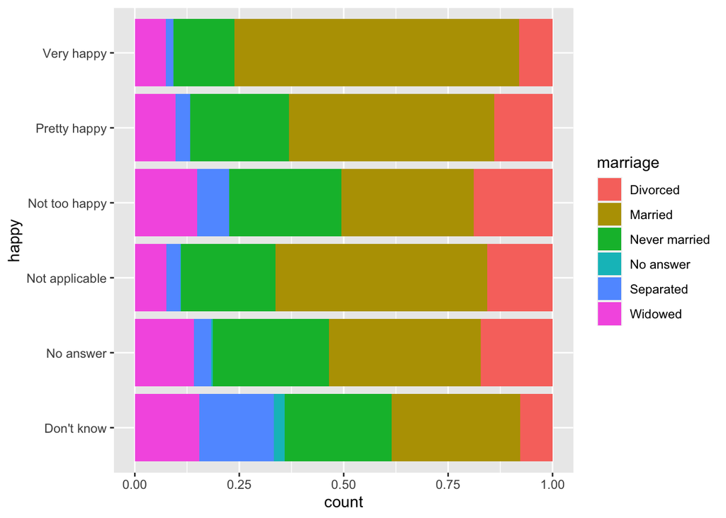

```r
ggplot(dat, aes(x = happy, fill = marriage)) + coord_flip() + geom_bar(position = 'fill')
```

This graph shows an interesting spread of marriage status across happiness ratings. It is evident that there is a lesser distribution of happy divorced and separated people than not happy. Married people are generally spread across the board, as are married people. Finally, there is a much greater amount of separated people that “dont know” if they’re happy than any others. Overall, this suggests that those with tough life events - divorced, widowed, and separated - identify as less happy than those who are married or have never been married.

**4) Does party affiliation affect the relationship you found in the last question?**

```r
partyaff <- dat %>%
  group_by(party, marriage) %>%
  summarize(count = n()) %>%
  arrange(desc(count))
partyaff
```

```
## # A tibble: 58 x 3
## # Groups:   party [10]
##    party              marriage      count
##    <fct>              <chr>         <int>
##  1 Not str democrat   Married        6895
##  2 Not str republican Married        5914
##  3 Strong democrat    Married        4885
##  4 Independent        Married        4819
##  5 Strong republican  Married        3941
##  6 Ind,near dem       Married        3725
##  7 Ind,near rep       Married        3226
##  8 Not str democrat   Never married  2873
##  9 Independent        Never married  2508
## 10 Ind,near dem       Never married  2176
## # … with 48 more rows
```

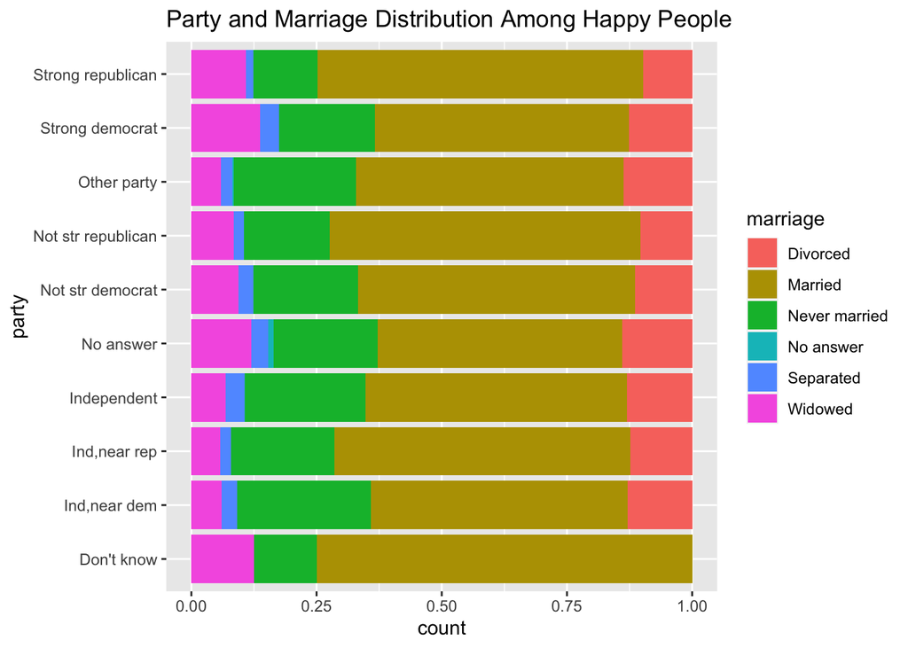

```r
partyaffhappy <- dat %>%
  filter(happy == "Very happy" | happy == "Pretty happy")

ggplot(partyaffhappy, aes(x = party, fill = marriage)) + coord_flip() + geom_bar(position = 'fill') + ggtitle("Party and Marriage Distribution Among Happy People")
```

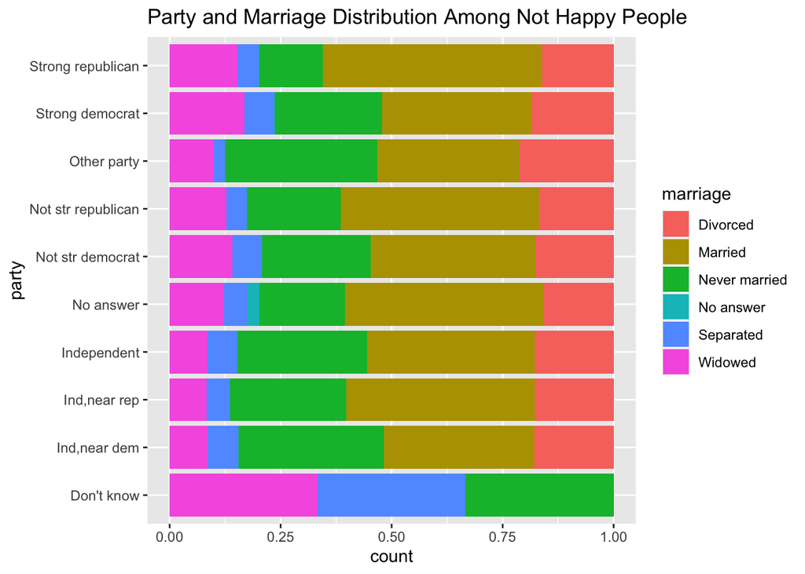

```r
partyaffsad <- dat %>%
  filter(!(happy == "Very happy" | happy == "Pretty happy"))

ggplot(partyaffsad, aes(x = party, fill = marriage)) + coord_flip() + geom_bar(position = 'fill') + ggtitle("Party and Marriage Distribution Among Not Happy People")
```

The first graph above shows party affiliation as it relates to marriage for happy people. In the graph above, we saw that happy people, as we define in the assignment, is distributed across each marriage type. Here, we see that there are minimal divorced people that don’t know their party affiliation. Beyond that, the distribution of married, never married, and widowed people is even across party affiliation.

Again for not happy people, there is a large amount of separated and widowed people that do not know their party. Perhaps those going through tough life events, like these populations, do not have time, interest, or energy to involve themselves in politics. Also, we see that divorced people nearly always identify with a party.

**5) How is marrital status related to the education of a respondent? What are possible reasons accounting for the patterns you see?**

```r
dat <- dat %>%
  mutate(education = as.numeric(education),
         age = as.numeric(age))

dat <- dat %>%
  mutate(party = factor(party)) %>%
  mutate(marriage = factor(marriage))


marry <- dat %>%
  filter(!is.na(education)) %>%
  group_by(marriage) %>%
  summarize(mean_education = mean(education)) %>%
  arrange(desc(mean_education))
marry
```

```
## # A tibble: 6 x 2
##   marriage      mean_education
##   <fct>                  <dbl>
## 1 No answer               15.5
## 2 Never married           13.4
## 3 Divorced                13.1
## 4 Married                 13.0
## 5 Separated               11.9
## 6 Widowed                 11.2
```

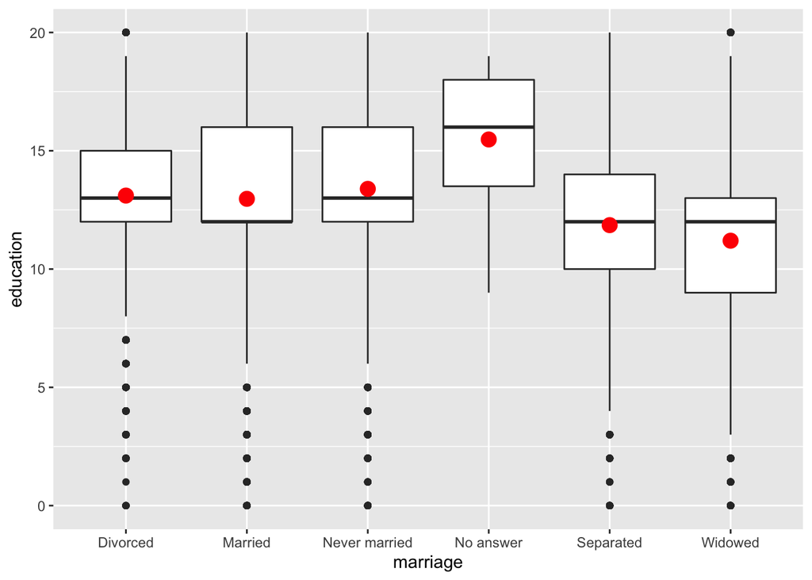

```r
dat <- dat %>%
  filter(!is.na(education))
ggplot(dat, aes(x = marriage, y = education)) + geom_boxplot() + stat_summary(fun = mean, geom = 'point', color = "red", size = 4)
```

There is a general relationship between marriage status and mean education. Never married, divorced, and married persons had a higher mean education status compared to separated and widowed persons. This could suggest that being widowed or separated are events that keep a person from continuing his or her education. Perhaps, separated and widowed people are more likely to be single parents, and therefore have to overcome higher obstacles to attend school.

**6) Explore two more interesting questions, and answer those questions using the GSS data.**

How is age related to happiness?

```r
ageHappy <- dat %>%
  mutate(happy = factor(happy)) %>%
  filter(!is.na(age)) %>%
  group_by(happy) %>%
  summarize(mean_age = mean(age))
ageHappy
```

```
## # A tibble: 6 x 2
##   happy          mean_age
##   <fct>             <dbl>
## 1 Don't know         54.9
## 2 No answer          46.5
## 3 Not applicable     46.1
## 4 Not too happy      46.5
## 5 Pretty happy       45.0
## 6 Very happy         47.1
```

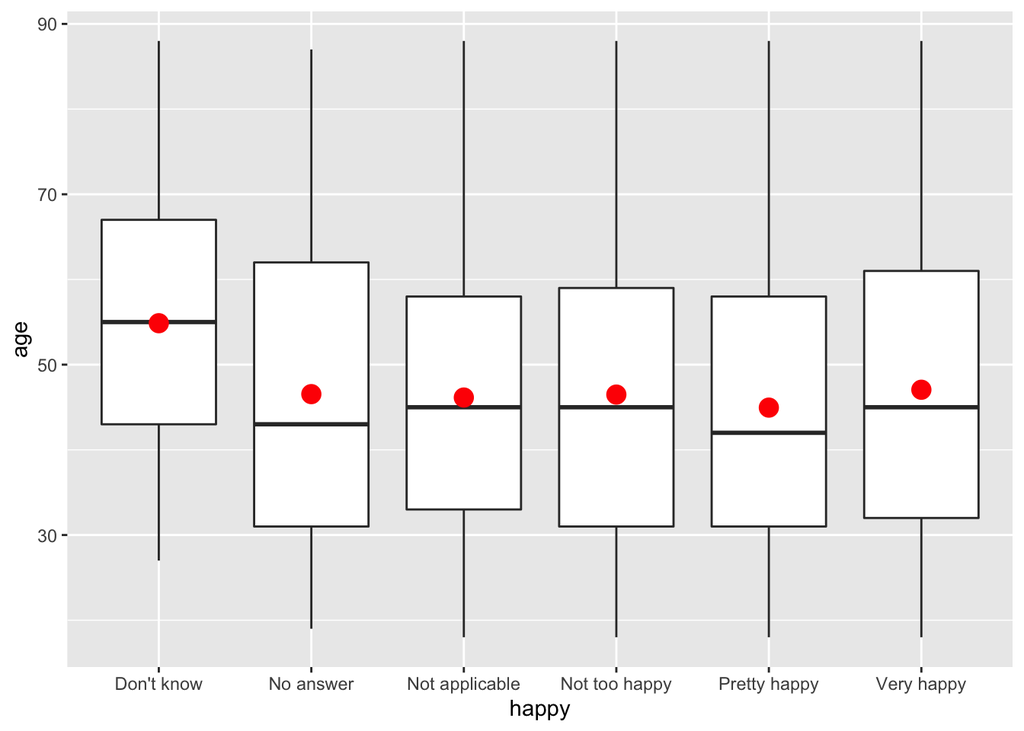

```r
ageHappyPlot<- dat %>%
  filter(!is.na(age))
ggplot(ageHappyPlot, aes(x = happy, y = age)) + geom_boxplot() + stat_summary(fun = mean, geom = 'point', color = "red", size = 4)
```

As a whole, I found this plot to be very interesting. From this simple analysis, it seems as if there is not a strong correlation between age and happiness. In fact, the mean value is very similar across all happiness ratings. However, there is a slight increase in mean age for those who don’t know how to rank their happiness. As shown in the boxplot, the range of values occurs at a higher age than the other happiness values. This suggests that younger people (under 30) are more strongly decisive in whether or not they are happy.

Income and happiness

```r
#dat <- dat %>%  rename('income' = 'Respondents income')
#na.omit(income)
#dat <- dat %>% mutate(income = as.numeric(income))
#dat <- dat %>%
  #filter(!is.na(income)) %>%
  #group_by(dat$income) %>%
  #summarize(numberHappiness = n()) %>%
  #arrange(desc(numberHappiness))
#ggplot(happiness, aes(x = income)) + geom_bar()
```

(Becca) I was unable to complete this plot. Here is my work from what I attempted. I would assume that income and happiness have a positive relationship to a certain point and then happiness would level off or perhaps even decrease.